# mlr3 Tutorial

Bernd Bischl & Marvin N. Wright

# Introduction and Overview

## `mlr3` Book

Best entry point to mlr3

Tutorial follows the book closely

[figure not shown]

## mlr3 Ecosystem and Package List

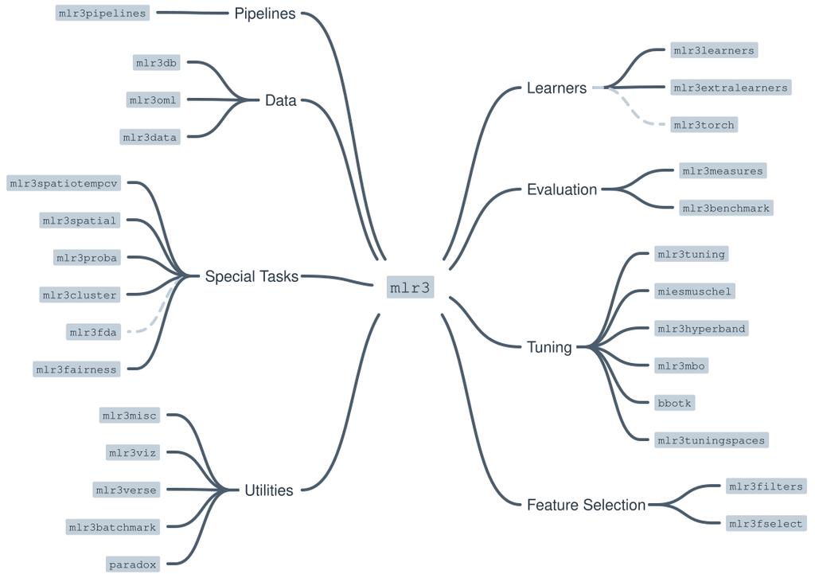

## Package Installation and Loading

`mlr3verse` package references all important packages of `mlr3` ecosystem

```r
library(mlr3verse)
```

But explicitly loading packages can be transparent – and some of us prefer that

```r
library(mlr3)
library(mlr3learners)
library(mlr3tuning)
library(mlr3pipelines)
```

## `mlr3` Design Principles

- OO system (with R6)
- Light on deps - only use stuff with clear benefits and no dep recursion hell
- Defensive programming and type safety
- Flexibility and efficiency trumps simplicity and convenience (still support latter conservatively)
- Proper and similar containers; data is tabular, also result data; use data.table, coz it’s fast and great (but note: heavy use of list cols)
- Emphasis on computation instead of presentation

## R6 Classes

R’s more recent OO system

Instances of a class are constructed with `$new()`

```r
foo = Foo$new(bar = 1)
```

We often replace this with sugar functions (see later)

## R6 - Fields, Active Bindings, Methods

Objects have mutable state, encapsulated in *fields*

Access and modify via `$` operator

```r
foo$bar = 2
```

Can also be *ABs*, which look like normal field-access or assign, but can run arbitrary code

(R6’s version of getters and setters)

So the above code could e.g. validate assign data

*Methods* are other functions associated with object

Can also change state

```r
foo$change_me()
```

## R6 - Reference Semantics

Objects are `environments`

So we can change their state via assignments

And if we pass them to functions, a reference is passed (different to R’s usual copy-on-write)

```r
# does not create a copy foo
foo2 = foo

# changes state of LHS
foo$bar = 3

# if foo is changed inside, caller-object is changed
do_something(foo)

# create copy
foo3 = foo$clone(deep = TRUE)
```

## Sugar Functions

Most `mlr3` objects are created with sugar functions

Slightly shorter and more convenient

E.g. `lrn()` creates learner object without `$new()`

```r
lrn("regr.rpart")
```

```
<LearnerRegrRpart:regr.rpart>: Regression Tree
* Model: -
* Parameters: xval=0
* Packages: mlr3, rpart
* Predict Types:  [response]
* Feature Types: logical, integer, numeric, factor, ordered
* Properties: importance, missings, selected_features, weights
```

We combine these with dictionaries (see next) and there is sugar for more than object creation

## Dictionaries

Common classes and constructors organized in dicts

Means: you can list and search

Associates keys with objects

```r
mlr_tasks
```

```
<DictionaryTask> with 22 stored values
Keys: ames_housing, bike_sharing, boston_housing, breast_cancer, california_housing, german_credit, ilpd, iris, kc_housing, moneyball, mtcars, optdigits, penguins, penguins_simple, pima, ruspini, sonar, spam, titanic, usarrests, wine, zoo
```

Sugar for object retrieval

```r
tsk("pima")
```

Dicts exist for tasks, learners, metrics, pipeline ops, etc.

Could even be changed locally by user

# Data and Basic Modeling

## ML Process and Common Steps

[figure not shown]

## Predefined Tasks

We ship some predefined tasks

Stored in `mlr_tasks` dict, access with `tsk()`

```r
mlr_tasks
```

```
<DictionaryTask> with 22 stored values
Keys: ames_housing, bike_sharing, boston_housing, breast_cancer, california_housing, german_credit, ilpd, iris, kc_housing, moneyball, mtcars, optdigits, penguins, penguins_simple, pima, ruspini, sonar, spam, titanic, usarrests, wine, zoo
```

```r
tsk_mtcars = tsk("mtcars")
tsk_mtcars
```

```
<TaskRegr:mtcars> (32 x 11): Motor Trends
* Target: mpg
* Properties: -
* Features (10):
  - dbl (10): am, carb, cyl, disp, drat, gear, hp, qsec, vs, wt
```

## Construct Your Own Task

```r
data("mtcars", package = "datasets")
tsk_mtcars = as_task_regr(mtcars, target = "mpg", id = "cars")
tsk_mtcars
```

```
<TaskRegr:cars> (32 x 11)
* Target: mpg
* Properties: -
* Features (10):
  - dbl (10): am, carb, cyl, disp, drat, gear, hp, qsec, vs, wt
```

## Task Mutators

Filter features

```r
tsk_mtcars_small = tsk("mtcars")
tsk_mtcars_small$select("cyl")
```

Filter rows

```r
tsk_mtcars_small$filter(2:3)
tsk_mtcars_small$data()
```

```
     mpg   cyl
   <num> <num>
1:  21.0     6
2:  22.8     4
```

Lots of operations for tasks, let’s move on for now

## Help Pages

For functions use `?` as usual

Help page of `mtcars` task via `?mlr_tasks_mtcars`

`$help()` for some objects like tasks / learners

```r
tsk("mtcars")$help()
```

## Learners

Stored in `mlr_learners` dict, access with `lrn()`

Dict is populated by loaded `mlr3` packages, e.g. `mlr3learners`, `mlr3extralearners`, `mlr3proba`

Dict sugar with `lrn()`

```r
lrn("regr.rpart")
```

```
<LearnerRegrRpart:regr.rpart>: Regression Tree
* Model: -
* Parameters: xval=0
* Packages: mlr3, rpart
* Predict Types:  [response]
* Feature Types: logical, integer, numeric, factor, ordered
* Properties: importance, missings, selected_features, weights
```

Dependencies are auto-loaded but not auto-installed

## Learner Metadata

- `$feature_types`: what learner can handle
- `$packages`: dependency list, auto-loaded
- `$properties`: e.g. can handle “missings” natively
- `$predict_types`: possible pred outputs, e.g. probs
- `$param_set`: set of available hyperparameters T Dict can be searched for learners with certain properties

## Learner Stages

[figure not shown]

## Training

```r
# train and inspect model
tsk_mtcars = tsk("mtcars")
lrn_rpart = lrn("regr.rpart")
lrn_rpart$train(tsk_mtcars)
lrn_rpart$model
```

```
n= 32

node), split, n, deviance, yval
      * denotes terminal node

1) root 32 1126.00 20.09
  2) cyl>=5 21  198.50 16.65
    4) hp>=192.5 7   28.83 13.41 *
    5) hp< 192.5 14   59.87 18.26 *
  3) cyl< 5 11  203.40 26.66 *
```

## Partition Data and Train on Subset

Randomly split task into disjoint sets

```r
splits = partition(tsk_mtcars)
splits
```

```
$train
 [1]  1  2  5  7 10 12 13 14 15 16 17 20 21 22 23 24 25 27 29 30 32

$test
 [1]  3  4  6  8  9 11 18 19 26 28 31

$validation
integer(0)
```

(Later we often don’t do this manually, see resampling)

Train on training set

```r
lrn_rpart$train(tsk_mtcars, row_ids = splits$train)
```

## Predict (on Subset)

```r
prediction = lrn_rpart$predict(tsk_mtcars, row_ids = splits$test)
```

Returns `Prediction` object

```r
prediction
```

```
<PredictionRegr> for 11 observations:
 row_ids truth response
       3  22.8     23.5
       4  21.4     15.4
       6  18.1     15.4
     ---   ---      ---
      26  27.3     23.5
      28  30.4     23.5
      31  15.0     15.4
```

Get tabular form:

```r
as.data.table(prediction)
```

## Hyperparameters

Represented as `ParamSet` object:

```r
lrn_rpart$param_set
```

```
<ParamSet(10)>
                id    class lower upper nlevels        default  value
            <char>   <char> <num> <num>   <num>         <list> <list>
 1:             cp ParamDbl     0     1     Inf           0.01 [NULL]
 2:     keep_model ParamLgl    NA    NA       2          FALSE [NULL]
 3:     maxcompete ParamInt     0   Inf     Inf              4 [NULL]
 4:       maxdepth ParamInt     1    30      30             30 [NULL]
 5:   maxsurrogate ParamInt     0   Inf     Inf              5 [NULL]
 6:      minbucket ParamInt     1   Inf     Inf <NoDefault[0]> [NULL]
 7:       minsplit ParamInt     1   Inf     Inf             20 [NULL]
 8: surrogatestyle ParamInt     0     1       2              0 [NULL]
 9:   usesurrogate ParamInt     0     2       3              2 [NULL]
10:           xval ParamInt     0   Inf     Inf             10      0
```

Used for overview, input validation and tuning setup

## HP Classes

| HP Class | HP Type |
| --- | --- |
| `ParamDbl` | Real-valued (numeric) |
| `ParamInt` | Integer |
| `ParamFct` | Categorical (factor) |
| `ParamLgl` | Logical / Boolean |
| `ParamUty` | Untyped |

## Getting and Setting HPs

During construction

```r
lrn_rpart = lrn("regr.rpart", maxdepth = 1)
lrn_rpart$param_set$values
```

```
$maxdepth
[1] 1

$xval
[1] 0
```

Update after construction

```r
# can do
lrn_rpart$param_set$values$cp = 0.5
# better
lrn_rpart$param_set$set_values(xval = 2, cp = 0.5)
```

## Evaluation of Predictions

Important step of applied ML

Same code as before:

```r
lrn_rpart = lrn("regr.rpart")
tsk_mtcars = tsk("mtcars")
splits = partition(tsk_mtcars)
lrn_rpart$train(tsk_mtcars, splits$train)
prediction = lrn_rpart$predict(tsk_mtcars, splits$test)
```

## Measure

Compare preds and labels for `Prediction` objs

Outputs a scalar

Stored in `mlr_measures` dict, access with `msr()`

```r
as.data.table(msr())[c(3, 4, 6, 7, 17, 45, 55),
  .(key, label, task_type, predict_type)]
```

```
Key: <key>
           key                 label task_type predict_type
        <char>                <char>    <char>       <char>
1:          ci            Default CI      <NA>     response
2:    ci.con_z     Conservative-Z CI      <NA>     response
3:  ci.holdout            Holdout CI      <NA>     response
4:      ci.ncv          Nested CV CI      <NA>     response
5: classif.fdr  False Discovery Rate   classif     response
6:   clust.wss Within Sum of Squares     clust    partition
7:  regr.medse  Median Squared Error      regr     response
```

## Use Measure to Score Pred Object

Mean absolute error

$f(y, \hat{y}) = | y - \hat{y} |$

```r
measure = msr("regr.mae")
measure
```

```
<MeasureRegrSimple:regr.mae>: Mean Absolute Error
* Packages: mlr3, mlr3measures
* Range: [0, Inf]
* Minimize: TRUE
* Average: macro
* Parameters: list()
* Properties: -
* Predict type: response
```

```r
prediction$score(measure)
```

```
regr.mae
   4.409
```

## Classification

Very similar interface

Let’s do penguins and score with accuracy

```r
tsk_penguins = tsk("penguins")
splits = partition(tsk_penguins)
lrn_rpart = lrn("classif.rpart")
measure = msr("classif.acc")
lrn_rpart$train(tsk_penguins, splits$train)
lrn_rpart$predict(tsk_penguins, splits$test)$score(measure)
```

```
classif.acc
     0.9474
```

## Binary Classification Tasks

`sonar` task is binary

```r
tsk_sonar = tsk("sonar")
tsk_sonar
```

```
<TaskClassif:sonar> (208 x 61): Sonar: Mines vs. Rocks
* Target: Class
* Properties: twoclass
* Features (60):
  - dbl (60): V1, V10, V11, V12, V13, V14, V15, V16, V17, V18, V19, V2, V20, V21, V22, V23, V24, V25, V26, V27, V28, V29, V3, V30, V31, V32, V33, V34, V35, V36, V37, V38, V39, V4, V40, V41, V42, V43, V44, V45, V46, V47, V48, V49, V5, V50, V51, V52, V53, V54, V55, V56, V57, V58, V59, V6, V60, V7, V8,…
```

```r
tsk_sonar$class_names
```

```
[1] "M" "R"
```

Especially for ROC metrics, better define pos class

```r
library(mlbench); data(Sonar)
tsk_sonar = as_task_classif(Sonar, target = "Class", positive = "M")
```

## Classification Predictions

Predict hard labels with `predict_type="response"`

Or vector of probs with `predict_type="prob"`

```r
lrn_rpart = lrn("classif.rpart", predict_type = "prob")
lrn_rpart$train(tsk_penguins, splits$train)
prediction = lrn_rpart$predict(tsk_penguins, splits$test)
prediction
```

```
<PredictionClassif> for 114 observations:
 row_ids     truth  response prob.Adelie prob.Chinstrap prob.Gentoo
       2    Adelie    Adelie      0.9895        0.01053           0
       3    Adelie    Adelie      0.9895        0.01053           0
       4    Adelie    Adelie      0.9895        0.01053           0
     ---       ---       ---         ---            ---         ---
     325 Chinstrap Chinstrap      0.0000        1.00000           0
     328 Chinstrap Chinstrap      0.0000        1.00000           0
     329 Chinstrap Chinstrap      0.0000        1.00000           0
```

## Classification Measures

To evaluate `"response"` predictions, you will need measures with `predict_type = "response"`

To evaluate probability predictions you will need `predict_type = "prob"`

```r
measures = msrs(c("classif.mbrier", "classif.logloss", "classif.acc"))
prediction$score(measures)
```

```
 classif.mbrier classif.logloss     classif.acc
         0.1059          1.8262          0.9474
```

## Confusion Matrix

```r
prediction$confusion
```

```
           truth
response    Adelie Chinstrap Gentoo
  Adelie        49         0      3
  Chinstrap      2        19      0
  Gentoo         1         0     40
```

## Thresholding

Default `response` hard label is class with max posterior prob

For binary tasks, this implies >= 50%

```r
task_credit = tsk("german_credit")
split = partition(task_credit)

lrn_rf = lrn("classif.ranger", predict_type = "prob")
lrn_rf$train(task_credit, split$train)
prediction = lrn_rf$predict(task_credit, split$test)
prediction$score(msr("classif.acc"))
```

```
classif.acc
     0.7667
```

```r
prediction$confusion
```

```
        truth
response good bad
    good  210  65
    bad    12  43
```

## Thresholding

For imbalanced tasks or unequal costs can change threshold

```r
prediction$set_threshold(0.85)
prediction$confusion
```

```
        truth
response good bad
    good   72   5
    bad   150 103
```

## ROC Metrics

```r
prediction$set_threshold(0.2)
prediction$score(msrs(c("classif.tpr", "classif.ppv", "classif.fbeta")))
```

```
  classif.tpr   classif.ppv classif.fbeta
       0.9955        0.6717        0.8022
```

```r
prediction$set_threshold(0.5)
prediction$score(msrs(c("classif.tpr", "classif.ppv", "classif.fbeta")))
```

```
  classif.tpr   classif.ppv classif.fbeta
       0.9459        0.7636        0.8451
```

```r
prediction$set_threshold(0.8)
prediction$score(msrs(c("classif.tpr", "classif.ppv", "classif.fbeta")))
```

```
  classif.tpr   classif.ppv classif.fbeta
       0.4369        0.9238        0.5933
```

## Threshold vs. Performance

```r
# cost matrix as given on the UCI page of the german credit data set
# https://archive.ics.uci.edu/ml/datasets/statlog+(german+credit+data)
costs = matrix(c(0, 1, 5, 0), nrow = 2)
dimnames(costs) = list(pred = task_credit$class_names, truth = task_credit$class_names)
print(costs)
```

```
      truth
pred   good bad
  good    0   5
  bad     1   0
```

```r
mm = msr("classif.costs", id = "cost", costs = costs, normalize = FALSE)
autoplot(prediction, measure = mm, type = "threshold")
```

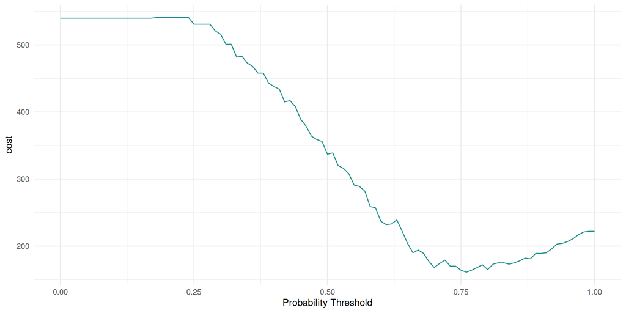

## ROC Curve

```r
autoplot(prediction, type = "roc")
```

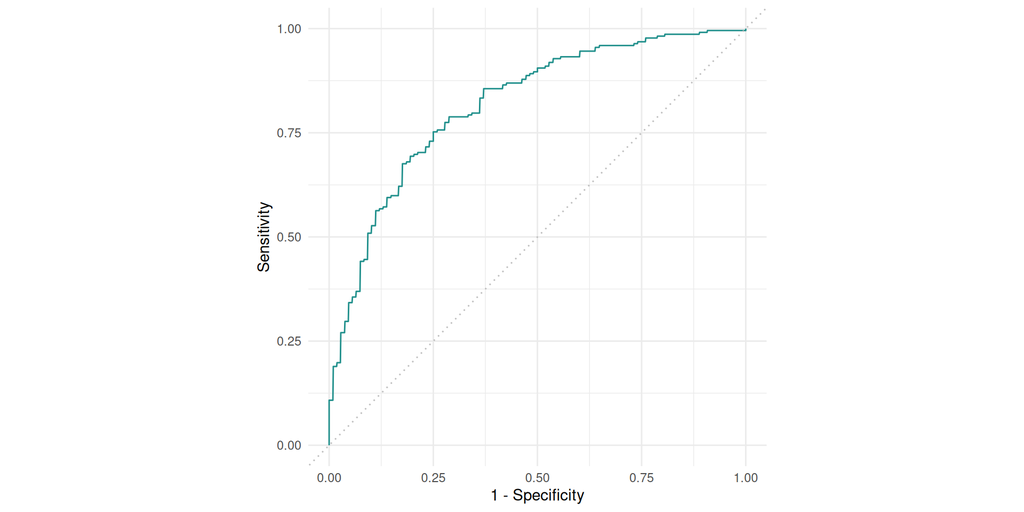

# Evaluation and Benchmarking

## Resampling

[figure not shown]

## Resampling Strategy

Define how to repeatedly split data into train and test sets

Stored in `mlr_resamplings` dict, access with `rmsp()`

```r
as.data.table(rsmp())[, .(key, label)]
```

```
Key: <key>
                   key                         label
                <char>                        <char>
 1:          bootstrap                     Bootstrap
 2:             custom                 Custom Splits
 3:          custom_cv Custom Split Cross-Validation
 4:                 cv              Cross-Validation
 5:            holdout                       Holdout
 6:           insample           Insample Resampling
 7:                loo                 Leave-One-Out
 8:          nested_cv                     Nested CV
 9: paired_subsampling            Paired Subsampling
10:        repeated_cv     Repeated Cross-Validation
11:        subsampling                   Subsampling
```

## Cross Validation

[figure not shown]

## Resampling Strategy

Holdout method

```r
holdout = rsmp("holdout", ratio = 0.8)
```

3-fold CV

```r
cv3 = rsmp("cv", folds = 3)
```

Subsampling with 3 repeats and 9/10 ratio

```r
ss390 = rsmp("subsampling", repeats = 3, ratio = 0.9)
```

2-repeats 5-fold CV

```r
rcv25 = rsmp("repeated_cv", repeats = 2, folds = 5)
```

## Resampling Experiments

`resample()` repeatedly fits learner on training set

Then predicts test data

Store preds in `ResampleResult`

```r
tsk_penguins = tsk("penguins")
lrn_rpart = lrn("classif.rpart")

rr = resample(tsk_penguins, lrn_rpart, cv3, store_models = TRUE)
rr
```

```
<ResampleResult> with 3 resampling iterations
  task_id    learner_id resampling_id iteration     prediction_test warnings errors
 penguins classif.rpart            cv         1 <PredictionClassif>        0      0
 penguins classif.rpart            cv         2 <PredictionClassif>        0      0
 penguins classif.rpart            cv         3 <PredictionClassif>        0      0
```

Scoring comes later, as separate operation

## Score and Aggregate

[figure not shown]

## Score and Aggregate Resample Result

Apply measure to each pred object via `$score()`

```r
rr$score(msr("classif.ce"))
```

```
    task_id    learner_id resampling_id iteration classif.ce
     <char>        <char>        <char>     <int>      <num>
1: penguins classif.rpart            cv         1    0.06957
2: penguins classif.rpart            cv         2    0.06087
3: penguins classif.rpart            cv         3    0.06140
Hidden columns: task, learner, resampling, prediction_test
```

`$aggregate()` aggregates all of these scores into scalar

```r
rr$aggregate(msr("classif.ce"))
```

```
classif.ce
   0.06395
```

## ResampleResult Objects

`Prediction` object for each resampling iteration

```r
rr$predictions()[[1]]
```

```
<PredictionClassif> for 115 observations:
 row_ids     truth  response
       2    Adelie    Adelie
       3    Adelie    Adelie
       8    Adelie    Adelie
     ---       ---       ---
     329 Chinstrap Chinstrap
     332 Chinstrap Chinstrap
     339 Chinstrap Chinstrap
```

## ResampleResult Objects

Can also be used for model inspection

```r
rr$learners[[1]]$model
```

```
n= 229

node), split, n, loss, yval, (yprob)
      * denotes terminal node

1) root 229 127 Adelie (0.44541 0.20524 0.34934)
  2) bill_length< 42.35 98   2 Adelie (0.97959 0.01020 0.01020) *
  3) bill_length>=42.35 131  52 Gentoo (0.04580 0.35115 0.60305)
    6) island=Dream,Torgersen 51   5 Chinstrap (0.09804 0.90196 0.00000) *
    7) island=Biscoe 80   1 Gentoo (0.01250 0.00000 0.98750) *
```

## Summary

```r
task = tsk("mtcars")
learner = lrn("regr.rpart")
resampling = rsmp("cv", folds = 3)

rr = resample(task, learner, resampling, store_models = TRUE)

rr$aggregate(msr("classif.ce"))
rr$score(msr("classif.ce"))

rr$predictions()[[1]]
rr$learners[[1]]$model
```

## Benchmarking

Compare *multiple learners on a single task*

Or *multiple learners on multiple tasks*

```r
tasks = tsks(c("german_credit", "sonar"))
learners = lrns(c("classif.rpart", "classif.ranger",
  "classif.featureless"), predict_type = "prob")
rsmp_cv2 = rsmp("cv", folds = 2)

design = benchmark_grid(tasks, learners, rsmp_cv2)
design
```

```
            task             learner resampling
          <char>              <char>     <char>
1: german_credit       classif.rpart         cv
2: german_credit      classif.ranger         cv
3: german_credit classif.featureless         cv
4:         sonar       classif.rpart         cv
5:         sonar      classif.ranger         cv
6:         sonar classif.featureless         cv
```

Design DT can also be manually constructed and controlled

## Benchmarking

Runs `resample()` on each row of the design

Collects the results in a `BenchmarkResult` object

```r
bmr = benchmark(design)
bmr
```

```
<BenchmarkResult> of 12 rows with 6 resampling runs
 nr       task_id          learner_id resampling_id iters warnings errors
  1 german_credit       classif.rpart            cv     2        0      0
  2 german_credit      classif.ranger            cv     2        0      0
  3 german_credit classif.featureless            cv     2        0      0
  4         sonar       classif.rpart            cv     2        0      0
  5         sonar      classif.ranger            cv     2        0      0
  6         sonar classif.featureless            cv     2        0      0
```

## Score Benchmark Result

`$score()` for each test set

```r
bmr$score()
```

```
       nr       task_id          learner_id resampling_id iteration     prediction_test classif.ce
    <int>        <char>              <char>        <char>     <int>              <list>      <num>
 1:     1 german_credit       classif.rpart            cv         1 <PredictionClassif>     0.2780
 2:     1 german_credit       classif.rpart            cv         2 <PredictionClassif>     0.2800
 3:     2 german_credit      classif.ranger            cv         1 <PredictionClassif>     0.2420
 4:     2 german_credit      classif.ranger            cv         2 <PredictionClassif>     0.2260
 5:     3 german_credit classif.featureless            cv         1 <PredictionClassif>     0.3200
 6:     3 german_credit classif.featureless            cv         2 <PredictionClassif>     0.2800
 7:     4         sonar       classif.rpart            cv         1 <PredictionClassif>     0.2788
 8:     4         sonar       classif.rpart            cv         2 <PredictionClassif>     0.2308
 9:     5         sonar      classif.ranger            cv         1 <PredictionClassif>     0.1827
10:     5         sonar      classif.ranger            cv         2 <PredictionClassif>     0.1731
11:     6         sonar classif.featureless            cv         1 <PredictionClassif>     0.4712
12:     6         sonar classif.featureless            cv         2 <PredictionClassif>     0.4615
Hidden columns: uhash, task, learner, resampling
```

## Aggregate Benchmark Result

```r
bmr$aggregate()
```

```
      nr       task_id          learner_id resampling_id iters classif.ce
   <int>        <char>              <char>        <char> <int>      <num>
1:     1 german_credit       classif.rpart            cv     2     0.2790
2:     2 german_credit      classif.ranger            cv     2     0.2340
3:     3 german_credit classif.featureless            cv     2     0.3000
4:     4         sonar       classif.rpart            cv     2     0.2548
5:     5         sonar      classif.ranger            cv     2     0.1779
6:     6         sonar classif.featureless            cv     2     0.4663
Hidden columns: resample_result
```

## BenchmarkResult Objects

Collection of multiple `ResampleResult` objects

```r
bmr$resample_result(1)
```

```
<ResampleResult> with 2 resampling iterations
       task_id    learner_id resampling_id iteration     prediction_test warnings errors
 german_credit classif.rpart            cv         1 <PredictionClassif>        0      0
 german_credit classif.rpart            cv         2 <PredictionClassif>        0      0
```

## BenchmarkResult as Table

Convert to a `data.table`

```r
as.data.table(bmr)
```

```
                                   uhash                        task                                         learner     resampling iteration          prediction
                                  <char>                      <list>                                          <list>         <list>     <int>              <list>
 1: d3e4712f-b956-432f-b36e-3673fe1bf9e4 <TaskClassif:german_credit>             <LearnerClassifRpart:classif.rpart> <ResamplingCV>         1 <PredictionClassif>
 2: d3e4712f-b956-432f-b36e-3673fe1bf9e4 <TaskClassif:german_credit>             <LearnerClassifRpart:classif.rpart> <ResamplingCV>         2 <PredictionClassif>
 3: 29a3313f-4cd4-4fe5-8436-f93c9487a0f7 <TaskClassif:german_credit>           <LearnerClassifRanger:classif.ranger> <ResamplingCV>         1 <PredictionClassif>
 4: 29a3313f-4cd4-4fe5-8436-f93c9487a0f7 <TaskClassif:german_credit>           <LearnerClassifRanger:classif.ranger> <ResamplingCV>         2 <PredictionClassif>
 5: 9ce70e43-be44-418c-ad99-d584b91adac7 <TaskClassif:german_credit> <LearnerClassifFeatureless:classif.featureless> <ResamplingCV>         1 <PredictionClassif>
 6: 9ce70e43-be44-418c-ad99-d584b91adac7 <TaskClassif:german_credit> <LearnerClassifFeatureless:classif.featureless> <ResamplingCV>         2 <PredictionClassif>
 7: 51bacc40-89dc-4694-95c9-66ad1bab4d6a         <TaskClassif:sonar>             <LearnerClassifRpart:classif.rpart> <ResamplingCV>         1 <PredictionClassif>
 8: 51bacc40-89dc-4694-95c9-66ad1bab4d6a         <TaskClassif:sonar>             <LearnerClassifRpart:classif.rpart> <ResamplingCV>         2 <PredictionClassif>
 9: 58a11a8c-4253-448c-b75c-2bc7bc20d108         <TaskClassif:sonar>           <LearnerClassifRanger:classif.ranger> <ResamplingCV>         1 <PredictionClassif>
10: 58a11a8c-4253-448c-b75c-2bc7bc20d108         <TaskClassif:sonar>           <LearnerClassifRanger:classif.ranger> <ResamplingCV>         2 <PredictionClassif>
11: d1292625-e45c-46a0-a2a3-1098b70fe8ae         <TaskClassif:sonar> <LearnerClassifFeatureless:classif.featureless> <ResamplingCV>         1 <PredictionClassif>
12: d1292625-e45c-46a0-a2a3-1098b70fe8ae         <TaskClassif:sonar> <LearnerClassifFeatureless:classif.featureless> <ResamplingCV>         2 <PredictionClassif>
```

## Visualize Benchmark Results

```r
autoplot(bmr, measure = msr("classif.acc"))
```

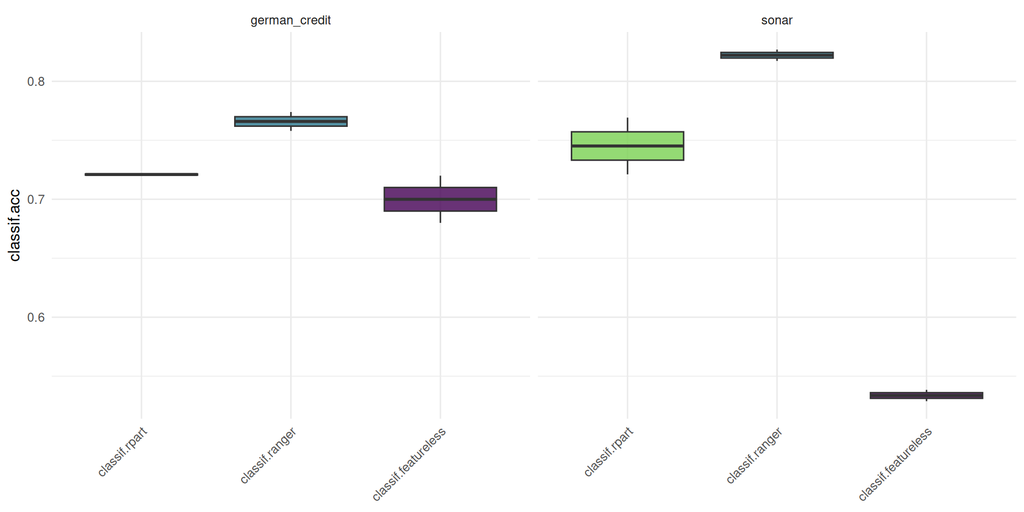

# Hyperparameter Optimization

## Hyperparameter Optimization Loop

[figure not shown]

## Learner and Search Space

Decide which HPs to tune and what range to tune

```r
as.data.table(lrn("classif.svm")$param_set)[1:12,
  .(id, class, lower, upper, nlevels)]
```

```
                 id    class lower upper nlevels
             <char>   <char> <num> <num>   <num>
 1:       cachesize ParamDbl  -Inf   Inf     Inf
 2:   class.weights ParamUty    NA    NA     Inf
 3:           coef0 ParamDbl  -Inf   Inf     Inf
 4:            cost ParamDbl     0   Inf     Inf
 5:           cross ParamInt     0   Inf     Inf
 6: decision.values ParamLgl    NA    NA       2
 7:          degree ParamInt     1   Inf     Inf
 8:         epsilon ParamDbl     0   Inf     Inf
 9:          fitted ParamLgl    NA    NA       2
10:           gamma ParamDbl     0   Inf     Inf
11:          kernel ParamFct    NA    NA       4
12:              nu ParamDbl  -Inf   Inf     Inf
```

## TuneToken

`to_tune()` to flag the HP for later tuning

```r
learner = lrn("classif.svm",
  type  = "C-classification",
  kernel = "radial",
  cost  = to_tune(1e-1, 1e5),
  gamma = to_tune(1e-1, 1)
)
learner
```

```
<LearnerClassifSVM:classif.svm>: Support Vector Machine
* Model: -
* Parameters: cost=<RangeTuneToken>, gamma=<RangeTuneToken>, kernel=radial, type=C-classification
* Packages: mlr3, mlr3learners, e1071
* Predict Types:  [response], prob
* Feature Types: logical, integer, numeric
* Properties: multiclass, twoclass
```

## Terminator

| Terminator | Construction and defaults |
| --- | --- |
| Clock Time | `trm("clock_time")` |
| Number of Evaluations | `trm("evals", n_evals = 100, k = 0)` |
| Performance Level | `trm("perf_reached", level = 0.1)` |
| Run Time | `trm("run_time", secs = 30)` |
| Stagnation | `trm("stagnation", iters = 10, threshold = 0)` |

## Terminator

`trm("combo")` allows to combine multiple terminators

`trm("none")` is used by tuners that terminate on their own

| Terminator | Construction and defaults |
| --- | --- |
| Combo | `trm("combo", any = TRUE)` |
| None | `trm("none")` |

## Tuning Instance

Sets up tuning objective and collects evals in archive

```r
tsk_sonar = tsk("sonar")
instance = ti(
  task = tsk_sonar,
  learner = learner,
  resampling = rsmp("cv", folds = 3),
  measures = msr("classif.ce"),
  terminator = trm("none")
)
instance
```

```
<TuningInstanceBatchSingleCrit>
* State:  Not optimized
* Objective: <ObjectiveTuningBatch:classif.svm_on_sonar>
* Search Space:
       id    class lower  upper nlevels
   <char>   <char> <num>  <num>   <num>
1:   cost ParamDbl   0.1 100000     Inf
2:  gamma ParamDbl   0.1      1     Inf
* Terminator: <TerminatorNone>
```

## Tuners as Black Box Optimizers

Stored in `mlr_tuners` dict, access with `tnr()`

| Tuner | Construction | Package |
| --- | --- | --- |
| Random Search | `tnr("random_search")` | `mlr3tuning` |
| Grid Search | `tnr("grid_search")` | `mlr3tuning` |
| CMA-ES | `tnr("cmaes")` | `adagio` |
| Gen. Simulated Annealing | `tnr("gensa")` | `GenSA` |
| Nonlinear Optimization | `tnr("nloptr")` | `nloptr` |
| Iterated Racing | `tnr("irace")` | `irace` |
| Hyperband | `tnr("hyperband")` | `mlr3hyperband` |
| Bayesian Optimization | `tnr("mbo")` | `mlr3mbo` |

## Grid Search

Exhaustively evaluate all HP combos in given ranges

```r
tuner = tnr("grid_search", resolution = 5, batch_size = 10)
tuner
```

```
<TunerBatchGridSearch>: Grid Search
* Parameters: batch_size=10, resolution=5
* Parameter classes: ParamLgl, ParamInt, ParamDbl, ParamFct
* Properties: dependencies, single-crit, multi-crit
* Packages: mlr3tuning, bbotk
```

## Control Parameters

Can be set as for learners in `$param_set`

```r
tuner$param_set
```

```
<ParamSet(3)>
                  id    class lower upper nlevels        default  value
              <char>   <char> <num> <num>   <num>         <list> <list>
1:        batch_size ParamInt     1   Inf     Inf <NoDefault[0]>     10
2:        resolution ParamInt     1   Inf     Inf <NoDefault[0]>      5
3: param_resolutions ParamUty    NA    NA     Inf <NoDefault[0]> [NULL]
```

## Triggering Tuning

Returns the best found HPC and performance

```r
tuner$optimize(instance)
```

```
    cost gamma learner_param_vals  x_domain classif.ce
   <num> <num>             <list>    <list>      <num>
1: 75000   0.1          <list[4]> <list[2]>     0.3266
```

Result also stored in `instance$result`

```r
instance$result
```

```
    cost gamma learner_param_vals  x_domain classif.ce
   <num> <num>             <list>    <list>      <num>
1: 75000   0.1          <list[4]> <list[2]>     0.3266
```

`$learner_param_vals`: optimal HPC + manually set stuff

`$x_domain` –> see trafos

## Analyze Results

Archive stores all evaluated HPCs

```r
as.data.table(instance$archive)
```

```
        cost gamma classif.ce runtime_learners           timestamp warnings errors  x_domain batch_nr  resample_result
       <num> <num>      <num>            <num>              <POSc>    <int>  <int>    <list>    <int>           <list>
 1:  25000.1 0.325     0.5046            0.059 2025-03-24 08:20:06        0      0 <list[2]>        1 <ResampleResult>
 2:  25000.1 0.775     0.5673            0.058 2025-03-24 08:20:06        0      0 <list[2]>        1 <ResampleResult>
 3:  25000.1 1.000     0.5673            0.043 2025-03-24 08:20:06        0      0 <list[2]>        1 <ResampleResult>
 4:  50000.1 0.325     0.5046            0.043 2025-03-24 08:20:06        0      0 <list[2]>        1 <ResampleResult>
 5:  50000.1 0.775     0.5673            0.043 2025-03-24 08:20:06        0      0 <list[2]>        1 <ResampleResult>
 6:  75000.0 0.100     0.3266            0.044 2025-03-24 08:20:06        0      0 <list[2]>        1 <ResampleResult>
 7:  75000.0 0.550     0.5480            0.043 2025-03-24 08:20:06        0      0 <list[2]>        1 <ResampleResult>
 8:  75000.0 0.775     0.5673            0.043 2025-03-24 08:20:06        0      0 <list[2]>        1 <ResampleResult>
 9: 100000.0 0.550     0.5480            0.050 2025-03-24 08:20:06        0      0 <list[2]>        1 <ResampleResult>
10:      0.1 0.100     0.5673            0.042 2025-03-24 08:20:07        0      0 <list[2]>        2 <ResampleResult>
11:      0.1 0.550     0.5673            0.052 2025-03-24 08:20:07        0      0 <list[2]>        2 <ResampleResult>
12:  25000.1 0.100     0.3266            0.044 2025-03-24 08:20:07        0      0 <list[2]>        2 <ResampleResult>
13:  25000.1 0.550     0.5480            0.044 2025-03-24 08:20:07        0      0 <list[2]>        2 <ResampleResult>
14:  50000.1 0.100     0.3266            0.043 2025-03-24 08:20:07        0      0 <list[2]>        2 <ResampleResult>
15:  50000.1 1.000     0.5673            0.044 2025-03-24 08:20:07        0      0 <list[2]>        2 <ResampleResult>
16:  75000.0 0.325     0.5046            0.053 2025-03-24 08:20:07        0      0 <list[2]>        2 <ResampleResult>
17: 100000.0 0.325     0.5046            0.042 2025-03-24 08:20:07        0      0 <list[2]>        2 <ResampleResult>
18:      0.1 0.325     0.5673            0.052 2025-03-24 08:20:08        0      0 <list[2]>        3 <ResampleResult>
19:      0.1 0.775     0.5673            0.042 2025-03-24 08:20:08        0      0 <list[2]>        3 <ResampleResult>
20:      0.1 1.000     0.5673            0.050 2025-03-24 08:20:08        0      0 <list[2]>        3 <ResampleResult>
21:  50000.1 0.550     0.5480            0.044 2025-03-24 08:20:08        0      0 <list[2]>        3 <ResampleResult>
22:  75000.0 1.000     0.5673            0.042 2025-03-24 08:20:08        0      0 <list[2]>        3 <ResampleResult>
23: 100000.0 0.100     0.3266            0.054 2025-03-24 08:20:08        0      0 <list[2]>        3 <ResampleResult>
24: 100000.0 0.775     0.5673            0.043 2025-03-24 08:20:08        0      0 <list[2]>        3 <ResampleResult>
25: 100000.0 1.000     0.5673            0.045 2025-03-24 08:20:08        0      0 <list[2]>        3 <ResampleResult>
        cost gamma classif.ce runtime_learners           timestamp warnings errors  x_domain batch_nr  resample_result
```

## Visualize Results

Visualize results as surface plot with `mlr3viz`

```r
autoplot(instance, type = "surface")
```

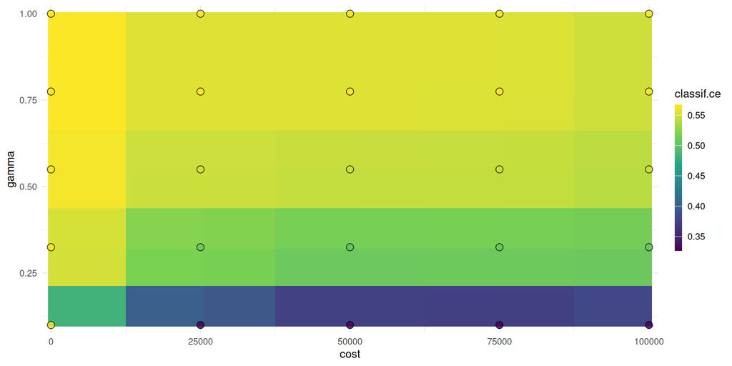

## Train Learner with Optimal HPC

```r
lrn_svm_tuned = lrn("classif.svm")
lrn_svm_tuned$param_set$values = instance$result_learner_param_vals
lrn_svm_tuned$train(tsk_sonar)$model
```

```
Call:
svm.default(x = data, y = task$truth(), type = "C-classification", kernel = "radial", gamma = 0.1, cost = 75000.025, probability = (self$predict_type == "prob"))


Parameters:
   SVM-Type:  C-classification
 SVM-Kernel:  radial
       cost:  75000

Number of Support Vectors:  205
```

## Trafos on Log Scale

```r
cost = runif(1000, log(1e-5), log(1e5))
```

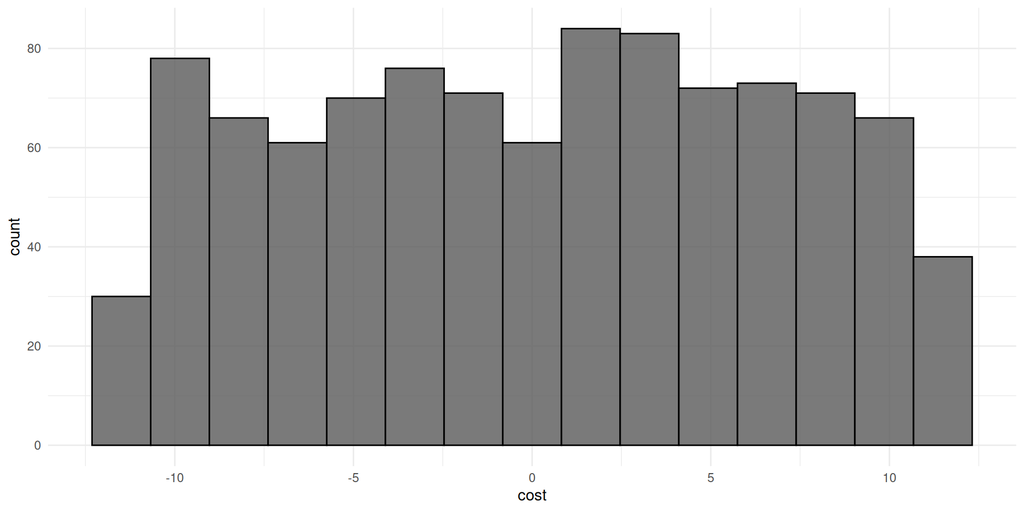

## Trafos on Log Scale

```r
exp_cost = exp(cost)
```

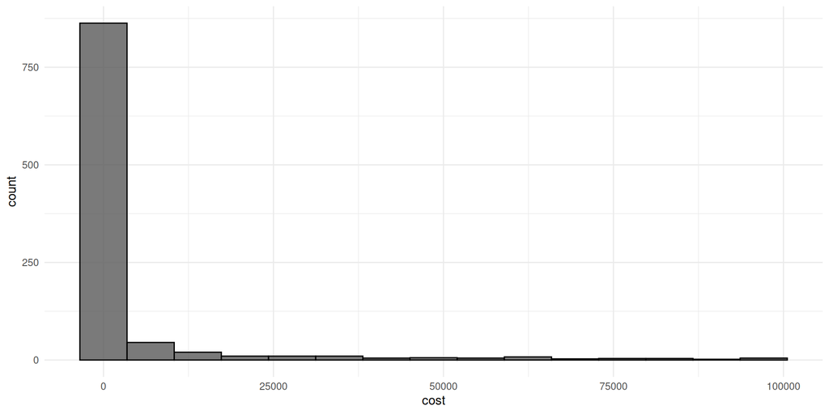

## Trafos on Log Scale

```r
learner = lrn("classif.svm",
  cost  = to_tune(1e-5, 1e5, logscale = TRUE),
  gamma = to_tune(1e-5, 1e5, logscale = TRUE),
  kernel = "radial",
  type = "C-classification"
)
```

## Convenient Tuning

`mlr3tuning` has some sugar functions

Same code as before

```r
tnr_grid_search = tnr("grid_search", resolution = 5, batch_size = 5)
lrn_svm = lrn("classif.svm",
  cost  = to_tune(1e-5, 1e5, logscale = TRUE),
  gamma = to_tune(1e-5, 1e5, logscale = TRUE),
  kernel = "radial",
  type = "C-classification"
)
rsmp_cv3 = rsmp("cv", folds = 3)
msr_ce = msr("classif.ce")
```

## Tuning with `tune`

Create tuning instance, then `$optimize()`

```r
instance = tune(
  tuner = tnr_grid_search,
  task = tsk_sonar,
  learner = lrn_svm,
  resampling = rsmp_cv3,
  measures = msr_ce
)
instance$result
```

```
    cost  gamma learner_param_vals  x_domain classif.ce
   <num>  <num>             <list>    <list>      <num>
1: 11.51 -5.756          <list[4]> <list[2]>     0.1443
```

## Summary

```r
lrn_rpart = lrn("classif.rpart",
  minsplit  = to_tune(2, 128, logscale = TRUE),
  minbucket = to_tune(1, 64, logscale = TRUE),
  cp        = to_tune(1e-04, 1e-1, logscale = TRUE)
)

instance = ti(
  task = tsk("pima"),
  learner = lrn_rpart,
  resampling = rsmp("cv", folds = 3),
  measures = msr("classif.ce"),
  terminator = trm("evals", n_evals = 100)
)
tuner = tnr("random_search", batch_size = 10)
tuner$optimize(instance)
```

## Tuning with `auto_tuner`

[figure not shown]

## Tuning with `auto_tuner`

Inherits from `Learner`

Runs `tune()` when `$train()` is called on train data

Then trains learner with optimal HPC on train data

```r
at = auto_tuner(
  tuner = tnr_grid_search,
  learner = lrn_svm,
  resampling = rsmp_cv3,
  measure = msr_ce
)
```

## Tuning with `auto_tuner`

```r
at
```

```
<AutoTuner:classif.svm.tuned>
* Model: list
* Parameters: list()
* Packages: mlr3, mlr3tuning, mlr3learners, e1071
* Predict Types:  [response], prob
* Feature Types: logical, integer, numeric
* Properties: multiclass, twoclass
* Search Space:
       id    class  lower upper nlevels
   <char>   <char>  <num> <num>   <num>
1:   cost ParamDbl -11.51 11.51     Inf
2:  gamma ParamDbl -11.51 11.51     Inf
```

## Nested Resampling

[figure not shown]

## Nested Resampling `AutoTuner`

Resampling `AutoTuner` with `resample()` or `benchmark()` does this naturally

```r
at = auto_tuner(
  tuner = tnr_grid_search,
  learner = lrn_svm,
  resampling = rsmp("cv", folds = 4),
  measure = msr_ce,
  id = "svm"
)

rr = resample(tsk_sonar, at, rsmp_cv3, store_models = TRUE)
```

Estim. perf of tuned learner: aggr. perf on all outer test sets

```r
rr$aggregate()
```

```
classif.ce
    0.1586
```

## Inner Tuning Results

Optimal configurations across all outer folds

```r
extract_inner_tuning_results(rr)
```

```
   iteration  cost  gamma classif.ce learner_param_vals  x_domain task_id learner_id resampling_id
       <int> <num>  <num>      <num>             <list>    <list>  <char>     <char>        <char>
1:         1 5.756 -5.756     0.1880          <list[4]> <list[2]>   sonar        svm            cv
2:         2 5.756 -5.756     0.2372          <list[4]> <list[2]>   sonar        svm            cv
3:         3 5.756 -5.756     0.1376          <list[4]> <list[2]>   sonar        svm            cv
```

## Inner Tuning Archives

Full tuning archives

```r
extract_inner_tuning_archives(rr)
```

```
    iteration    cost   gamma classif.ce x_domain_cost x_domain_gamma runtime_learners           timestamp warnings errors batch_nr  resample_result task_id learner_id resampling_id
        <int>   <num>   <num>      <num>         <num>          <num>            <num>              <POSc>    <int>  <int>    <int>           <list>  <char>     <char>        <char>
 1:         1 -11.513 -11.513     0.4317     1.000e-05      1.000e-05            0.043 2025-03-24 08:20:16        0      0        1 <ResampleResult>   sonar        svm            cv
 2:         1   0.000  -5.756     0.2447     1.000e+00      3.162e-03            0.051 2025-03-24 08:20:16        0      0        1 <ResampleResult>   sonar        svm            cv
 3:         1   0.000   5.756     0.4317     1.000e+00      3.162e+02            0.046 2025-03-24 08:20:16        0      0        1 <ResampleResult>   sonar        svm            cv
 4:         1   5.756   0.000     0.4317     3.162e+02      1.000e+00            0.047 2025-03-24 08:20:16        0      0        1 <ResampleResult>   sonar        svm            cv
 5:         1   5.756   5.756     0.4317     3.162e+02      3.162e+02            0.057 2025-03-24 08:20:16        0      0        1 <ResampleResult>   sonar        svm            cv
 6:         1 -11.513  -5.756     0.4317     1.000e-05      3.162e-03            0.043 2025-03-24 08:20:17        0      0        2 <ResampleResult>   sonar        svm            cv
 7:         1 -11.513   5.756     0.4317     1.000e-05      3.162e+02            0.043 2025-03-24 08:20:17        0      0        2 <ResampleResult>   sonar        svm            cv
 8:         1   0.000 -11.513     0.4317     1.000e+00      1.000e-05            0.054 2025-03-24 08:20:17        0      0        2 <ResampleResult>   sonar        svm            cv
 9:         1   0.000  11.513     0.4317     1.000e+00      1.000e+05            0.046 2025-03-24 08:20:17        0      0        2 <ResampleResult>   sonar        svm            cv
10:         1  11.513 -11.513     0.2158     1.000e+05      1.000e-05            0.043 2025-03-24 08:20:17        0      0        2 <ResampleResult>   sonar        svm            cv
11:         1  -5.756  11.513     0.4317     3.162e-03      1.000e+05            0.044 2025-03-24 08:20:17        0      0        3 <ResampleResult>   sonar        svm            cv
12:         1   0.000   0.000     0.4317     1.000e+00      1.000e+00            0.047 2025-03-24 08:20:17        0      0        3 <ResampleResult>   sonar        svm            cv
13:         1   5.756  -5.756     0.1880     3.162e+02      3.162e-03            0.050 2025-03-24 08:20:17        0      0        3 <ResampleResult>   sonar        svm            cv
```

[output cut: 63 more lines]

## Defining Search Spaces with `ps`

Full control over with `ps`

```r
search_space = ps(
  cost  = p_dbl(lower = 1e-1, upper = 1e5),
  kernel = p_fct(c("radial", "linear")),
  shrinking = p_lgl()
)
```

Pass to tuning instance

```r
ti(tsk_sonar, lrn("classif.svm", type = "C-classification"), rsmp_cv3,
  msr_ce, trm("none"), search_space = search_space)
```

```
<TuningInstanceBatchSingleCrit>
* State:  Not optimized
* Objective: <ObjectiveTuningBatch:classif.svm_on_sonar>
* Search Space:
          id    class lower  upper nlevels
      <char>   <char> <num>  <num>   <num>
1:      cost ParamDbl   0.1 100000     Inf
2:    kernel ParamFct    NA     NA       2
3: shrinking ParamLgl    NA     NA       2
* Terminator: <TerminatorNone>
```

## Complex Transformations

```r
search_space = ps(
  cost = p_dbl(-1, 1, trafo = function(x) exp(x)),
  kernel = p_fct(c("polynomial", "radial")),
  .extra_trafo = function(x, param_set) {
    if (x$kernel == "polynomial") x$cost = x$cost + 2
    x
  }
)
search_space$trafo(list(cost = 1, kernel = "radial"))
```

```
$cost
[1] 2.718

$kernel
[1] "radial"
```

```r
search_space$trafo(list(cost = 1, kernel = "polynomial"))
```

```
$cost
[1] 4.718

$kernel
[1] "polynomial"
```

## Predefined Search Spaces

Can be stored in and retrieved with mlr3tuningspaces

```r
library(mlr3tuningspaces)
as.data.table(mlr_tuning_spaces)[1:3, .(key, label)]
```

```
Key: <key>
                      key                             label
                   <char>                            <char>
1: classif.glmnet.default   Classification GLM with Default
2:    classif.glmnet.rbv1 Classification GLM with RandomBot
3:    classif.glmnet.rbv2 Classification GLM with RandomBot
```

## Recommended Search Spaces

Sugar `lts()`: learner tuning space

```r
lts_rpart = lts("classif.rpart.default")
lts_rpart
```

```
<TuningSpace:classif.rpart.default>: Classification Rpart with Default
          id  lower upper levels logscale
      <char>  <num> <num> <list>   <lgcl>
1:  minsplit 2.0000 128.0 [NULL]     TRUE
2: minbucket 1.0000  64.0 [NULL]     TRUE
3:        cp 0.0001   0.1 [NULL]     TRUE
```

Can be directly used for tuning

## Summary

```r
lrn_rpart = lrn("classif.rpart",
  minsplit  = to_tune(2, 128, logscale = TRUE),
  minbucket = to_tune(1, 64, logscale = TRUE),
  cp        = to_tune(1e-04, 1e-1, logscale = TRUE)
)

at = auto_tuner(
  tuner = tnr("random_search", batch_size = 10),
  learner = lrn_rpart,
  resampling = rsmp("cv", folds = 4),
  measure = msr("classif.ce"),
)

rr = resample(tsk("pima"), at, rsmp("cv", folds = 3), store_models = TRUE)
```

# Sequential Pipelines

## Sequential Pipelines

Workflows including data preprocessing, building ensemble-models, or more complicated meta-models

`PipeOp`s are the building blocks

[figure not shown]

`PipeOp`s are connected to form a `Graph` or pipeline

## PipeOp

Short for Pipeline Operator

Includes a `$train()` and a `$predict()` method

Has a `$param_set` field that defines the hyperparameters

Constructed with the `po()` function

```r
library(mlr3pipelines)

po_pca = po("pca", center = TRUE)
po_pca
```

```
PipeOp: <pca> (not trained)
values: <center=TRUE>
Input channels <name [train type, predict type]>:
  input [Task,Task]
Output channels <name [train type, predict type]>:
  output [Task,Task]
```

## PipeOp Train

`PipeOp` includes a `$train()` and a `$predict()` method

The `po("pca")` applies a principal component analysis

```r
tsk_small = tsk("penguins_simple")$select(c("bill_depth", "bill_length"))
poin = list(tsk_small$clone()$filter(1:5))
poout = po_pca$train(poin) # poin: Task in a list
poout # list with a single element 'output'
```

```
$output
<TaskClassif:penguins> (5 x 3): Simplified Palmer Penguins
* Target: species
* Properties: multiclass
* Features (2):
  - dbl (2): PC1, PC2
```

```r
poout[[1]]$head(3)
```

```
   species    PC1       PC2
    <fctr>  <num>     <num>
1:  Adelie 0.1561  0.005716
2:  Adelie 1.2677  0.789534
3:  Adelie 1.5336 -0.174460
```

## PipeOp State

The training phase typically generates a particular model of the data, which is saved as the internal `$state` field

The `$state` field of `po("pca")` contains the rotation matrix

```r
po_pca$state
```

```
Standard deviations (1, .., p=2):
[1] 1.513 1.034

Rotation (n x k) = (2 x 2):
                PC1     PC2
bill_depth  -0.6116 -0.7911
bill_length  0.7911 -0.6116
```

## PipeOp Predict

This state is then used during predictions and applied to new data

```r
tsk_onepenguin = tsk_small$clone()$filter(42)
poin = list(tsk_onepenguin)
poout = po_pca$predict(poin)
poout[[1]]$data()
```

```
   species   PC1    PC2
    <fctr> <num>  <num>
1:  Adelie 1.555 -1.455
```

## Graph

`PipeOp`s represent individual computational steps in machine learning pipelines

These pipelines themselves are defined by `Graph` objects

A `Graph` is a collection of `PipeOp`s with “edges” that guide the flow of data

## Graph

The most convenient way of building a `Graph` is to connect a sequence of `PipeOp`s using the `%>>%`-operator

```r
po_mutate = po("mutate",
  mutation = list(bill_ratio = ~bill_length / bill_depth)
)
po_scale = po("scale")
graph = po_mutate %>>% po_scale
graph
```

```
Graph with 2 PipeOps:
     ID         State sccssors prdcssors
 <char>        <char>   <char>    <char>
 mutate <<UNTRAINED>>    scale
  scale <<UNTRAINED>>             mutate
```

## Graph

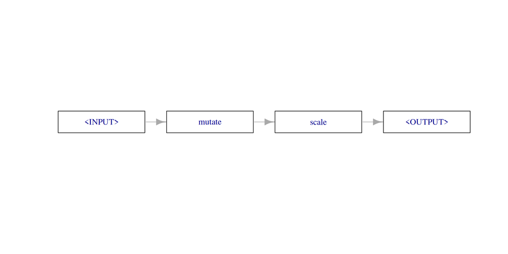

```r
graph$plot(horizontal = TRUE)
```

## Sequential Learner-Pipelines

Most common application for `mlr3pipelines` is to preprocess data before feeding it into a `Learner`

[figure not shown]

## Learners as PipeOps

`Learner` objects can be converted to `PipeOp`s

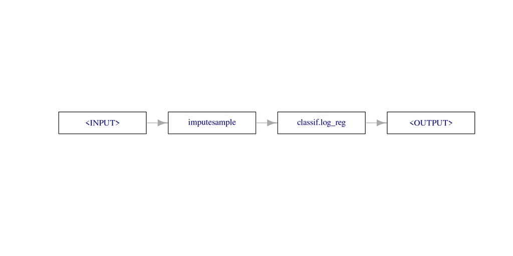

```r
lrn_logreg = lrn("classif.log_reg")
graph = po("imputesample") %>>% lrn_logreg
graph$plot(horizontal = TRUE)
```

## Graphs as Learners

To use a `Graph` as a `Learner` with an identical interface, it can be wrapped in a `GraphLearner` object with `as_learner()`

```r
glrn_sample = as_learner(graph)
glrn_mode = as_learner(po("imputemode") %>>% lrn_logreg)

design = benchmark_grid(tsk("pima"), list(glrn_sample, glrn_mode),
  rsmp("cv", folds = 3))
bmr = benchmark(design)
aggr = bmr$aggregate()[, .(learner_id, classif.ce)]
aggr
```

```
                     learner_id classif.ce
                         <char>      <num>
1: imputesample.classif.log_reg     0.2253
2:   imputemode.classif.log_reg     0.2292
```

## Configuring Pipeline Hyperparameters

`PipeOp` hyperparameters are collected together in the `$param_set` of a graph and prefixed with the ID of the `PipeOp`

```r
graph = po("scale", center = FALSE, scale = TRUE, id = "scale") %>>%
  po("scale", center = TRUE, scale = FALSE, id = "center") %>>%
  lrn("classif.rpart", cp = 1)
unlist(graph$param_set$values)
```

```
      scale.center        scale.scale       scale.robust      center.center       center.scale      center.robust   classif.rpart.cp classif.rpart.xval
                 0                  1                  0                  1                  0                  0                  1                  0
```

# Non-Sequential Pipelines

## Non-Sequential Pipelines

Non-sequential pipelines can perform more complex operations

Using the `gunion()` function, we can instead combine multiple `PipeOp`s, `Graph`s, or a mixture of both, into a parallel `Graph`

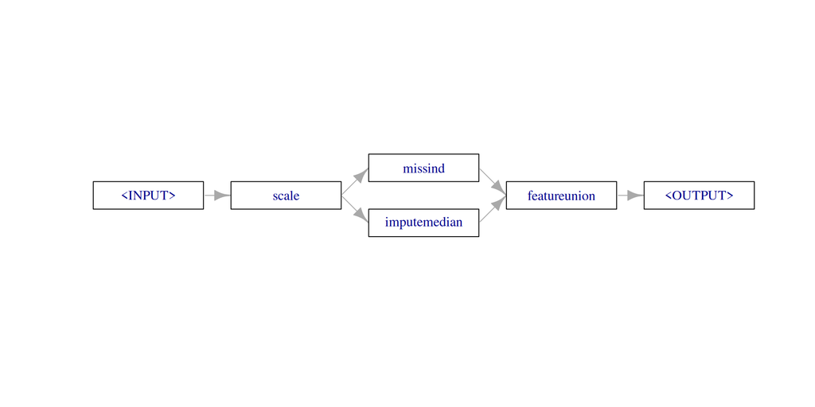

```r
graph = po("scale", center = TRUE, scale = FALSE) %>>%
  gunion(list(
    po("missind"),
    po("imputemedian")
  )) %>>%
  po("featureunion")

graph$plot(horizontal = TRUE)
```

## Common Patterns and ppl()

Many common problems in ML can be well solved by the same pipelines

`ppl("bagging", graph)` creates a bagging ensemble

`ppl("branch", graphs)` creates a branch

`ppl("robustify")` common preprocessing steps

`ppl("stacking", base_learners, super_learner)` creates a stacking ensemble

## Branching

`po("branch")` creates multiple paths such that data can only flow through *one* of these as determined by the `selection` hyperparameter

[figure not shown]

use `po("unbranch")` (with the same arguments as `"branch"`) to ensure that the outputs are merged into one result object

## Branching

```r
library(mlr3oml)
otsk_mnist = otsk(id = 3573)
tsk_mnist = as_task(otsk_mnist)$
  filter(sample(70000, 1000))$
  select(otsk_mnist$feature_names[sample(700, 100)])
```

## Branching

Do nothing `po("nop")`

Apply PCA `po("pca")`

Remove constant features `po("removeconstants")` then apply the Yeo-Johnson transform `po("yeojohnson")`

```r
paths = c("nop", "pca", "yeojohnson")

graph = po("branch", paths, id = "brnchPO") %>>%
  gunion(list(
    po("nop"),
    po("pca"),
    po("removeconstants", id = "rm_const") %>>%
      po("yeojohnson", id = "YJ")
  )) %>>% po("unbranch", paths, id = "unbrnchPO")
```

## Branching

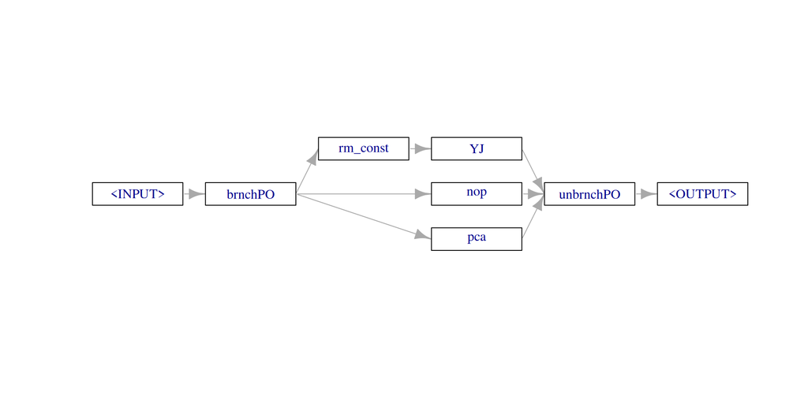

```r
graph$plot(horizontal = TRUE)
```

## Branching

The output of this `Graph` depends on the setting of the `branch.selection` hyperparameter

```r
# use the "PCA" path
graph$param_set$values$brnchPO.selection = "pca"
# new PCA columns
head(graph$train(tsk_mnist)[[1]]$feature_names)
```

```
[1] "PC1" "PC2" "PC3" "PC4" "PC5" "PC6"
```

```r
# use the "No-Op" path
graph$param_set$values$brnchPO.selection = "nop"
# same features
head(graph$train(tsk_mnist)[[1]]$feature_names)
```

```
[1] "pixel3"  "pixel6"  "pixel24" "pixel29" "pixel32" "pixel34"
```

## Tune Branch Pipeline

Branching can even be used to tune which of several learners is most appropriate for a given dataset

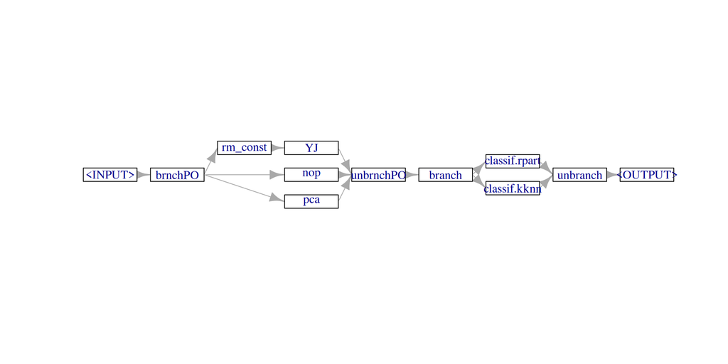

```r
graph_learner = graph %>>%
  ppl("branch", lrns(c("classif.rpart", "classif.kknn")))
graph_learner$plot(horizontal = TRUE)
```

## Tune Branch Pipeline

Tuning the `selection` hyperparameters can help determine which of the possible options work best in combination

```r
graph_learner = as_learner(graph_learner)

graph_learner$param_set$set_values(
  brnchPO.selection = to_tune(paths),
  branch.selection = to_tune(c("classif.rpart", "classif.kknn")),
  classif.kknn.k = to_tune(p_int(1, 32,
    depends = branch.selection == "classif.kknn"))
)

instance = tune(tnr("grid_search"), tsk_mnist, graph_learner,
  rsmp("repeated_cv", folds = 3, repeats = 3), msr("classif.ce"))

instance$archive$data[order(classif.ce)[1:5],
  .(brnchPO.selection, classif.kknn.k, branch.selection, classif.ce)]

autoplot(instance)
```

# Additional Features

- Error handling with encapsulation and fallbacks
- Parallelization with `future`, `mlr3batchmark` and `rush`
- Controlled logging with `lgr` package

[figure not shown]